# Programming for R Analytics Final Project

Name: Sathwik Chenna Madhavuni Andrew ID: schennam

Due Dec 16

### Introduction

This project serves as the helping guide for the Pittsbugh government municipality to analyse the pittsburgh neighbourhood areas and come up with the rebate program so that they can reduce the stormwater runoff. The data is taken from the Pittsburgh region data center. Data has been cleaned, analyzed and proper judgements were made. Finally, the value of the installation of trees and rain gardens are calculated and appropriate decisions are taken. Hence, the cost effective strategies are found and might be implemented.

### 3. Data Preparation

For each property, there are so many date values, which mean, properties were sold many times. Only the latest sale date is being considered here so that we consider their latest value.

Land use areas dataframe has been pivoted such that we get the sqft area values of bulidings, trees, impervious and open space areas.

### 4. Joining of Data

Property assessments, sale details and land use details dataframes are joined using PARID as the Primary Key. Now, for each property, we have the sale and land details.

Sewershed data has been added at the end after the rebate calculation has been done for the convinience.

### 5. Data Filtering and Formating

There are many sales which are of less importance and can mislead us. Few of them are ‘LOVE an AFFECTION SALE’ and ‘TAX SALE’. Such unnecessary sales have been removed and only ‘VALID’ and ‘OTHER VALID’ sales are taken. Also, there are few sales where the price is very less. For example, for one such property,it is $2000. Such properties are removed. Such properties can skew our model and hence they are removed. Please find the distribution of the price graph.

HOMESTEADFLAG flag has got empty spaces if the properties are not occupied by the owners. They have been replaced by ‘RENT’ keywords.

Zipcode has got strings and they have been formatted as ‘FACTOR’ for the regression analysis.

### 6.Data Exploration via plots

Following graph shows the distribution of prices in the data. This graph helps us to understand the data and then use the regression model.

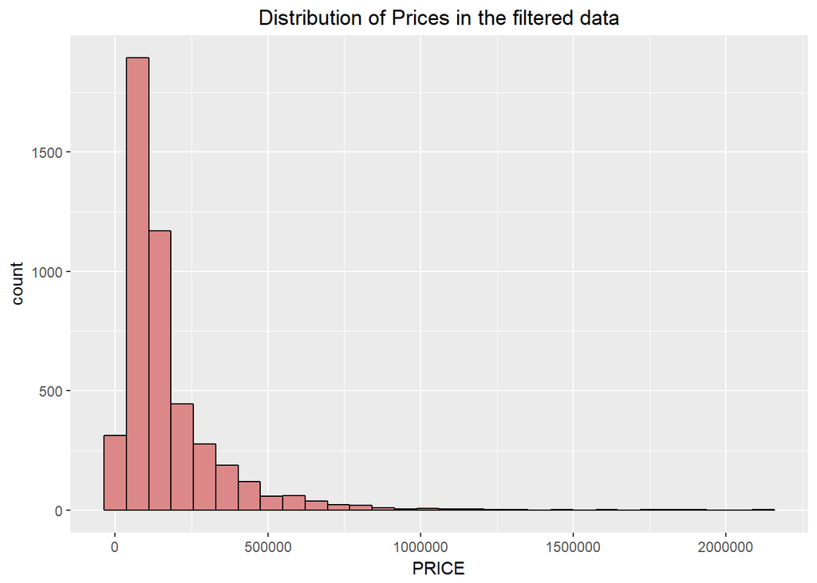

```r
ggplot(valid.final.sample,aes(x=PRICE)) + geom_histogram(colour="black", fill="#DD8888")+ggtitle("Distribution of Prices in the filtered data") +
  theme(plot.title = element_text(hjust = 0.5))
```

#### b. Distribution of price vs Condition and Owners

The price is varying with different owners and with different conditions of the property. These factors are really influencing the prices, and they have been used for the regression plot.

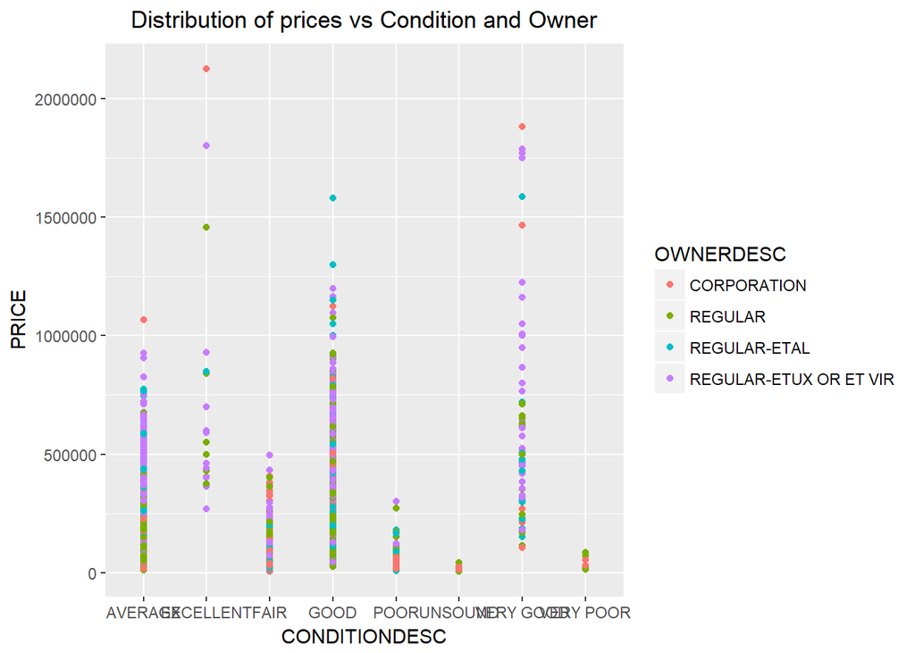

```r
ggplot(valid.final.sample,aes(x=CONDITIONDESC,y=PRICE,col=OWNERDESC)) + geom_point()+ggtitle("Distribution of prices vs Condition and Owner") +   theme(plot.title = element_text(hjust = 0.5))
```

#### c. Distribution of price vs Area of the property

Lotarea is also causing the varation in the prices. Zipcode is also a predictor in the prices. We are taking the zipcode as the representation of the expensive and the least expensive areas and hence zipcodes accounts for the variation in the price.

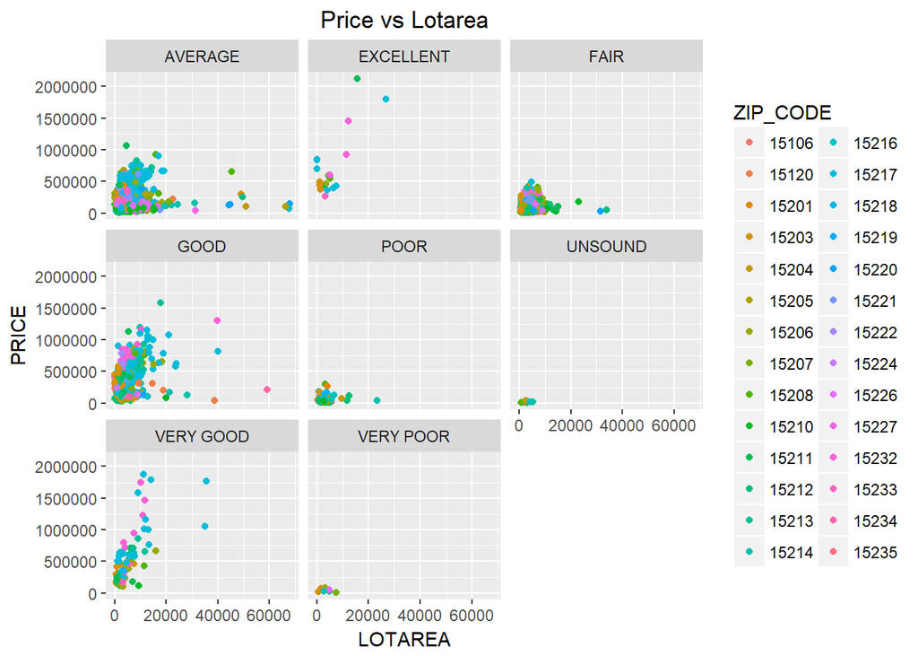

```r
ggplot(data = valid.final.sample, aes(y = PRICE, x = LOTAREA, color = ZIP_CODE))   + geom_point() +  facet_wrap(~CONDITIONDESC) +ggtitle("Price vs Lotarea") +  theme(plot.title = element_text(hjust = 0.5))
```

### 7. Finding the correlation among the variables

In order to perform the regression analysis, we need the variables which are highly correlated with the PRICE value. We need to account all the causal effects in the regression equation. We need to remove the selection bias from the model.

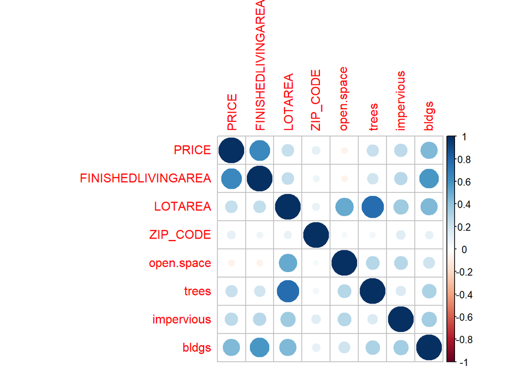

```r
regression.dataset<-select(valid.final.sample, PRICE, FINISHEDLIVINGAREA, LOTAREA ,ZIP_CODE, open.space  ,  trees, impervious,bldgs)
regression.dataset[is.na(regression.dataset)]<- 0
project.corrplot<-hetcor(regression.dataset)
corrplot(project.corrplot$correlations)
```

### 8. Summary table of the final sample

Following is the sample taken for the regression model:

```r
head(valid.final.sample)
```

```
##              PARID PROPERTYCITY               MUNIDESC         SCHOOLDESC
## 1 0046N00310000000   PITTSBURGH 25th Ward - PITTSBURGH City Of Pittsburgh
## 2 0046N00295000000   PITTSBURGH 25th Ward - PITTSBURGH City Of Pittsburgh
## 3 0046P00111000000   PITTSBURGH 25th Ward - PITTSBURGH City Of Pittsburgh
## 4 0046K00268000000   PITTSBURGH 26th Ward - PITTSBURGH City Of Pittsburgh
## 5 0028E00169000000   PITTSBURGH  4th Ward - PITTSBURGH City Of Pittsburgh
## 6 0028G00326000000   PITTSBURGH  4th Ward - PITTSBURGH City Of Pittsburgh
##                OWNERDESC       USEDESC LOTAREA HOMESTEADFLAG YEARBLT
## 1                REGULAR    TWO FAMILY    8225                  1920
## 2            CORPORATION SINGLE FAMILY    1725                  1910
## 3 REGULAR-ETUX OR ET VIR    TWO FAMILY    2500                  1900
## 4           REGULAR-ETAL SINGLE FAMILY    9420                  1920
## 5 REGULAR-ETUX OR ET VIR SINGLE FAMILY    2500                  1910
## 6            CORPORATION SINGLE FAMILY    2500                  1900
##   CONDITIONDESC BEDROOMS FULLBATHS HALFBATHS FINISHEDLIVINGAREA ZIP_CODE
```

[output cut: 27 more lines]

### 9. Multiple Linear Regression Model

After doing the explanatory analysis of the data, and the required correlation graphs, we have now sort of understood which variables are actually effecting the price. Following variables are taken as predictors for the multiple linear regression model: PRICE is the y variable.

We are considering the log-level plot here to increase the linearity of the model. Hence, the interpreation would be the different for this i.e. it is in terms of percentages of y with one unit of x.

```r
model<-lm(log(PRICE)~ FINISHEDLIVINGAREA+ CONDITIONDESC+ LOTAREA +  CONDITIONDESC + OWNERDESC  +ZIP_CODE  + open.space + trees ,valid.final.sample)
summary(model)
```

```
##
## Call:
## lm(formula = log(PRICE) ~ FINISHEDLIVINGAREA + CONDITIONDESC +
##     LOTAREA + CONDITIONDESC + OWNERDESC + ZIP_CODE + open.space +
##     trees, data = valid.final.sample)
##
## Residuals:
##      Min       1Q   Median       3Q      Max
## -2.93951 -0.25476  0.03109  0.29458  2.11719
##
## Coefficients:
##                                   Estimate Std. Error t value Pr(>|t|)
## (Intercept)                      1.027e+01  1.949e-01  52.672  < 2e-16 ***
## FINISHEDLIVINGAREA               3.197e-04  1.034e-05  30.907  < 2e-16 ***
## CONDITIONDESCEXCELLENT           7.065e-01  1.067e-01   6.619 4.04e-11 ***
## CONDITIONDESCFAIR               -4.595e-01  2.107e-02 -21.803  < 2e-16 ***
## CONDITIONDESCGOOD                3.739e-01  2.333e-02  16.026  < 2e-16 ***
## CONDITIONDESCPOOR               -6.854e-01  5.680e-02 -12.066  < 2e-16 ***
## CONDITIONDESCUNSOUND            -1.676e+00  1.580e-01 -10.605  < 2e-16 ***
## CONDITIONDESCVERY GOOD           5.248e-01  6.011e-02   8.731  < 2e-16 ***
## CONDITIONDESCVERY POOR          -9.888e-01  1.669e-01  -5.924 3.36e-09 ***
## LOTAREA                          1.781e-05  3.183e-06   5.593 2.36e-08 ***
## OWNERDESCREGULAR                 3.167e-01  2.139e-02  14.806  < 2e-16 ***
## OWNERDESCREGULAR-ETAL            4.457e-01  2.733e-02  16.308  < 2e-16 ***
## OWNERDESCREGULAR-ETUX OR ET VIR  4.619e-01  2.351e-02  19.646  < 2e-16 ***
## ZIP_CODE15120                    3.649e-01  2.167e-01   1.684 0.092285 .
## ZIP_CODE15201                    6.636e-01  1.949e-01   3.405 0.000666 ***
## ZIP_CODE15203                    8.726e-01  1.951e-01   4.472 7.93e-06 ***
## ZIP_CODE15204                   -2.731e-03  1.966e-01  -0.014 0.988913
## ZIP_CODE15205                    3.088e-01  1.974e-01   1.565 0.117713
## ZIP_CODE15206                    6.973e-01  1.945e-01   3.584 0.000341 ***
## ZIP_CODE15207                    2.694e-01  1.958e-01   1.376 0.168925
## ZIP_CODE15208                    7.830e-01  1.983e-01   3.949 7.95e-05 ***
## ZIP_CODE15210                   -1.289e-01  1.943e-01  -0.663 0.507173
## ZIP_CODE15211                    4.060e-01  1.954e-01   2.078 0.037764 *
## ZIP_CODE15212                    2.041e-01  1.940e-01   1.052 0.292851
## ZIP_CODE15213                    8.838e-01  1.977e-01   4.471 7.99e-06 ***
## ZIP_CODE15214                    1.239e-01  1.961e-01   0.632 0.527592
## ZIP_CODE15216                    2.182e-01  1.953e-01   1.117 0.263891
## ZIP_CODE15217                    1.032e+00  1.940e-01   5.319 1.10e-07 ***
## ZIP_CODE15218                    9.258e-01  2.054e-01   4.507 6.73e-06 ***
## ZIP_CODE15219                    2.795e-01  2.004e-01   1.395 0.163200
## ZIP_CODE15220                    1.736e-01  1.972e-01   0.880 0.378672
## ZIP_CODE15221                    6.923e-01  2.032e-01   3.408 0.000661 ***
## ZIP_CODE15222                    1.298e+00  2.496e-01   5.200 2.08e-07 ***
## ZIP_CODE15224                    7.108e-01  1.962e-01   3.623 0.000295 ***
## ZIP_CODE15226                    3.662e-01  1.942e-01   1.886 0.059406 .
## ZIP_CODE15227                   -9.791e-04  2.001e-01  -0.005 0.996095
## ZIP_CODE15232                    1.201e+00  1.989e-01   6.041 1.65e-09 ***
## ZIP_CODE15233                    4.793e-01  2.076e-01   2.308 0.021027 *
## ZIP_CODE15234                    3.003e-01  2.071e-01   1.450 0.147172
## ZIP_CODE15235                   -2.713e-01  3.846e-01  -0.705 0.480652
## open.space                       1.719e-05  8.303e-06   2.070 0.038502 *
## trees                           -1.010e-05  4.304e-06  -2.348 0.018940 *
## ---
## Signif. codes:  0 '***' 0.001 '**' 0.01 '*' 0.05 '.' 0.1 ' ' 1
##
## Residual standard error: 0.4704 on 4607 degrees of freedom
## Multiple R-squared:  0.6728, Adjusted R-squared:  0.6699
## F-statistic: 231.1 on 41 and 4607 DF,  p-value: < 2.2e-16
```

### 9. Interpreting the coefficients of the model

Since our variables of interest are trees and open.space. Let us consider the coefficients of these two varibles.

TREE: trees -0.000010103 0.000004304 -2.348 0.018940 * the coefficient of tree is -0.000010103 and it is significant at 95% level. which mean, for every unit increase in the sq ft of trees, there is ((exp^0.000010103)-1)*100% percentage decrease in price. it is decreasing due to the negative value.

OPEN SPACE: open.space 0.000017187 0.000008303 2.070 0.038502 * the coefficient of open.space is 0.000017187 and it is significant at 95% level. which mean, for every unit increase in the sq ft of open.space, there is ((exp^0.000017187)-1)*100% percentage increase in price. it is increasing due to the positive coefficient value.

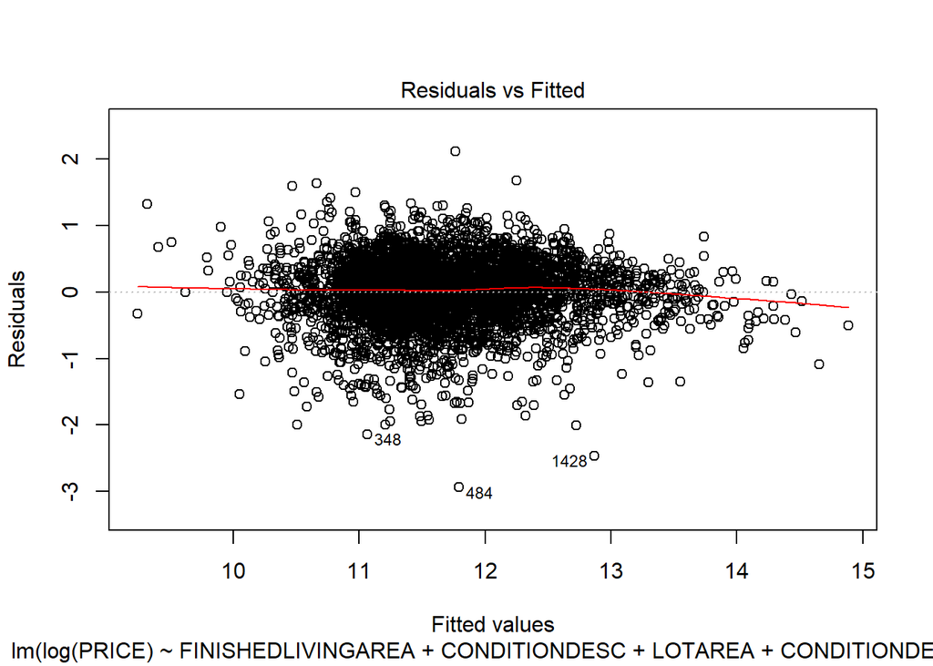

```r
plot(model, which = 1)
```

The Residuals and Fitted Values plot digram shows there is enough homoscedasticity in the final data sample we have chosen. Hence, we can move forward with this model.

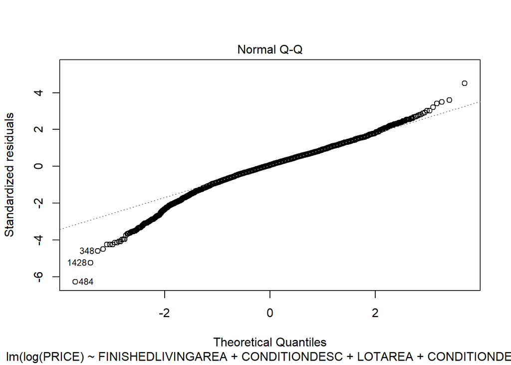

```r
plot(model,which=2)
```

### Question 1

1. How much do residential property owners value - if at all - exterior open space?

**ANSWER**

The coefficient of open.space from the regression model can be used to answer this: we are finding the value of open space for each property and then summing it up. Finally dividing the total value by the total open space and thereby we get the mean value of open space per sq ft.

```r
open.space.coefficient.percent <-(exp(model$coefficients['open.space'])-1)*100
summarized.properties.sample<-valid.final.sample
summarized.properties.sample<-mutate(summarized.properties.sample, open.space.value = (PRICE*(open.space.coefficient.percent/100)))
mean.value.per.sq.ft.of.open.space<- sum(summarized.properties.sample$open.space.value)/sum(summarized.properties.sample$open.space)

print(mean.value.per.sq.ft.of.open.space)
```

```
## [1] 0.003711241
```

The mean value of open space per square feet is 0.003711241.

### Question 2

2. How much do residential property owners value - if at all - trees?

**ANSWER** The coefficient of trees from the regression model can be used to answer this:

we are finding the value of trees for each property and then summing it up. Finally dividing the total value by the total trees space and thereby we get the mean value of trees per sq ft.

```r
trees.coefficient.percent <-(exp(model$coefficients['trees'])-1)*100
summarized.properties.sample<-mutate(summarized.properties.sample,trees.value = (PRICE*(trees.coefficient.percent/100)))
mean.value.per.sq.ft.trees<- sum(summarized.properties.sample$trees.value)/sum(summarized.properties.sample$trees)

print(mean.value.per.sq.ft.trees)
```

```
## [1] -0.001154409
```

The mean value of trees per square feet is -0.001154409.

2. How much do residential property owners value - if at all - trees?

**ANSWER** The coefficient of trees from the regression model can be used to answer this:

we are finding the value of trees for each property and then summing it up. Finally dividing the total value by the number of trees space and thereby we get the mean value of each tree

```r
summarized.properties.sample<-mutate(summarized.properties.sample,trees.value = (PRICE*(trees.coefficient.percent/100)))
summarized.properties.sample<-mutate(summarized.properties.sample,no.of.trees = (trees/(pi*12.5*12.5)))
mean.value.per.tree<- sum((summarized.properties.sample$trees.value)/sum(summarized.properties.sample$no.of.trees))

print(mean.value.per.tree)
```

```
## [1] -0.566669
```

The mean value of per tree is -0.566669

### Question 3

3. What is the mean rebate per square foot of rain garden and per tree the municipality should offer property owners to incentivize their installation? See Section 3 for additional assumptions.

**ANSWER** The mean rebate can be calculated by adding the value of open space or tree by its corresponding installation costs. From the data given, we can find out the mean installation cost per sqft of rain garden is 6.

From the data given, we can find out the mean installation cost per tree is 20. Adding those two installation costs to the compensation value, we get the following results:

```r
mean.reabte.per.sq.ft.of.rain.garden<-mean.value.per.sq.ft.of.open.space + 6
mean.reabte.per.tree<-abs(mean.value.per.tree) + 20
```

```r
mean.reabte.per.sq.ft.of.rain.garden
```

```
## [1] 6.003711
```

```r
mean.reabte.per.tree
```

```
## [1] 20.56667
```

### Question 4

4. On the basis of rebate per overflow reduced, what five areas of the city (sewersheds) are the most cost effective at reducing combined sewer overflows?

The top five areas of the city (sewersheds) which are the most cost effective at reducing combined sewer overflows:

```r
head(final.data.sample,n=5)
```

```
## # A tibble: 5 x 6
##   sewershed total.rebate total.overflow.reduced mean.cso cso.reduced
##      <fctr>        <dbl>                  <dbl>    <dbl>       <dbl>
## 1      M-15     15.30528               744.1786     0.94    699.5279
## 2      A-60   2691.73809            130878.6609     0.91 119099.5814
## 3      M-19    309.06122             15027.2860     0.85  12773.1931
## 4      M-29  13311.22855            647223.3578     0.85 550139.8541
## 5      M-16    691.76349             33635.1739     0.80  26908.1391
## # ... with 1 more variables: rebate.per.cso.overflow.reduced <dbl>
```

### Conclusion

With reference to the facts and derivates provided, we can conclude that installing trees in the open space of the M15, A60, M19, M29, M16 sewersheds is the most cost effective strategy for the Pitstburgh municipality.

#### REFERENCES

Blackhurst. MF. (2017). “Parcel Scale Green Infrastructure Siting and Cost Effectiveness Analysis.” http://sb.ucsur.pitt.edu/green-infrastructure/

Allegheny County. âAllegheny County Urban Tree Canopy.â Division of Computer Services Geographic Information Systems Group, 2010. http://www.pasda.psu.edu/uci/MetadataDisplay.aspx?entry=PASDA&file=AlleghenyCountyUrbanTreeCanopy2010.xml&dataset=1203.